# Introduction to linear modelling

Dr. Laurie Baker

07/12/2020

# 1 Learning Objectives

## 1.1 Exploratiory Data Analysis

- What is the difference between a continuous and categorical variable?
- What is variation and covariation?
- Where does Exploratory Data Analysis fit in with analysis?
- How to use plots to explore variation in
  - A continuous variable
  - A categorical variable
- How to use plots to explore covariation between
  - Two continuous variables
  - A categorical and continuous variable.

## 1.2 Model Basics

- What is a model family and fitted model?
- What is the difference between a response and an explanatory variable?

## 1.3 Model Construction

- How to construct a linear model in R?
- What are the slope and intercept in a linear model?
- Picking out key information from the model summary table.
- How to extract specific parameters from the model object.

## 1.4 Assessing Model Fit

- How to inspect model residuals to assess model fit?
- How to pick out key information from the table from a fitted model.
- How to use Adjusted R-squared and AIC to compare models.

# 2 Import the libraries

```r
#install.packages(tidyverse)
#install.packages(broom)
#install.packages(GGally)

library(tidyverse)
library(broom)
library(GGally)
```

# 3 Exploratory Data Analysis

## 3.1 Read in the data

```r
salaries <- read_csv("../data/faculty-data.csv")

salaries <- salaries %>%
              mutate(department = as_factor(department))
```

## 3.2 Explore the data

- What are the variables in our data set?

```r
head(salaries)
```

```
## # A tibble: 6 x 6
##     ids department   bases experience raises salary
##   <dbl> <fct>        <dbl>      <dbl>  <dbl>  <dbl>
## 1     1 sociology   39012.          3  2122. 45379.
## 2     2 biology     51872.          9   542. 56747.
## 3     3 english     64341.          3   543. 65971.
## 4     4 informatics 68975.          2  1737. 72449.
## 5     5 statistics  78262.          9   470. 82492.
## 6     6 sociology   40527.          3  1884. 46180.
```

- How many departments are in the data? How many employees are in each department?

```r
summary(salaries)
```

```
##       ids               department     bases         experience
##  Min.   :  1.00   sociology  :20   Min.   :37247   Min.   :0.00
##  1st Qu.: 25.75   biology    :20   1st Qu.:48071   1st Qu.:3.00
##  Median : 50.50   english    :20   Median :59432   Median :5.00
##  Mean   : 50.50   informatics:20   Mean   :60226   Mean   :4.82
##  3rd Qu.: 75.25   statistics :20   3rd Qu.:72671   3rd Qu.:7.25
##  Max.   :100.00                    Max.   :87010   Max.   :9.00
##      raises           salary
##  Min.   : 450.6   Min.   :42827
##  1st Qu.: 481.6   1st Qu.:54746
##  Median : 540.4   Median :62375
##  Mean   :1033.5   Mean   :65448
##  3rd Qu.:1741.0   3rd Qu.:78632
##  Max.   :2177.4   Max.   :91342
```

Using `View()`, what does each row in the data.frame represent?

- What’s the difference between a continuous and a categorical (factor or discrete) variable?

**Hint:** Country is a categorical variable, Height is a continous variable

### 3.2.1 Plotting the data

- Plotting a single continuous variable

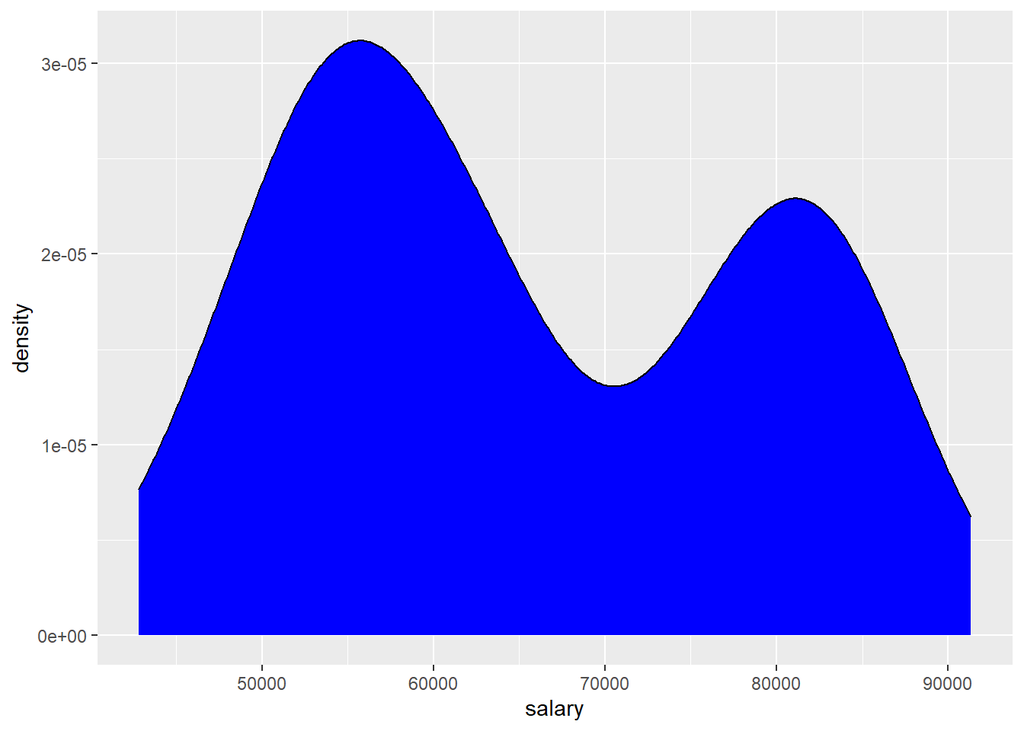

```r
ggplot(data = salaries) +
   geom_density(aes(salary), fill = "blue")
```

- Plotting a single categorical variable

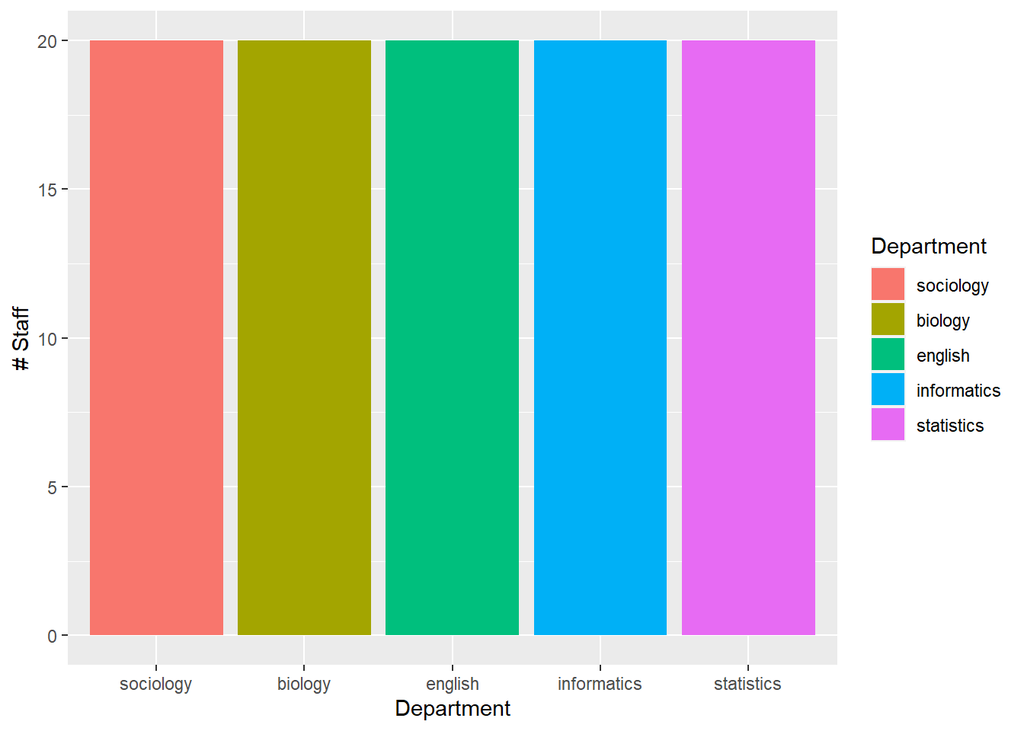

```r
ggplot(data = salaries) +
   geom_bar(aes(x = department, fill = department)) +
   labs(x = "Department", y = "# Staff", fill = "Department")
```

- Relationships between two continuous variables

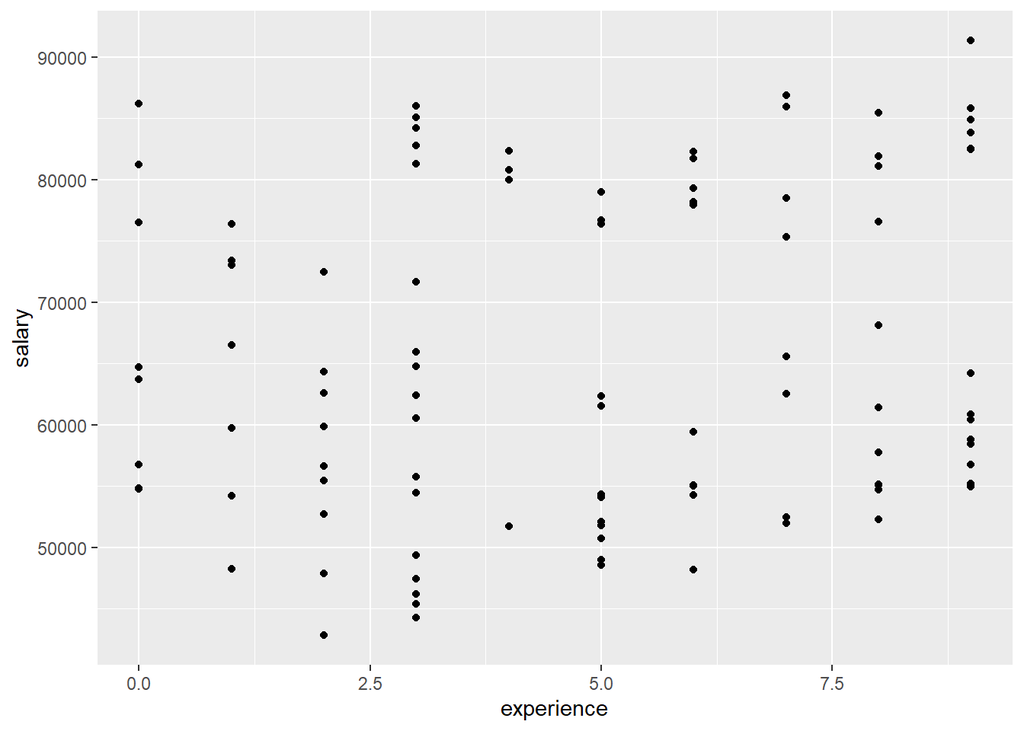

```r
ggplot(data = salaries) +
  geom_point(aes(x = experience, y = salary))
```

- Relationships between a discrete and continous variable

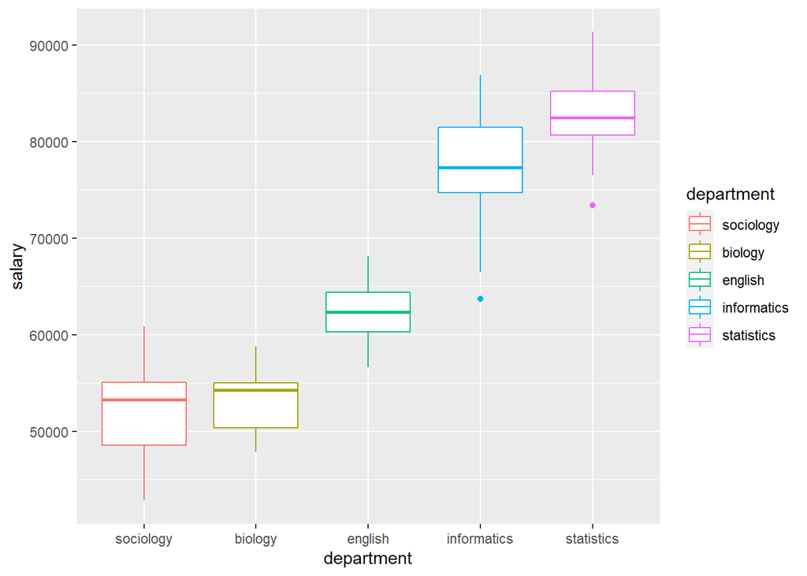

```r
ggplot(data = salaries) +
  geom_boxplot(aes(x = department, y = salary, color = department))
```

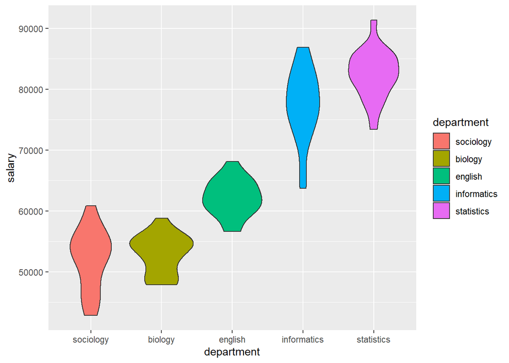

```r
ggplot(data = salaries) +
  geom_violin(aes(x = department, y = salary, fill = department))
```

- Looking at the plot, which departments have the highest salaries? Do you think the departments are very different from one another?

# 4 Constructing a linear model

## 4.1 The relationship between salary and experience is the same across all departments.

Each department has the same starting salary and the same increase in salary with experience.

### 4.1.1 Exercise:

- What are our response and explanatory variables in this case?

```r
m1 <- lm(salary ~ experience, data = salaries)
```

```r
summary(m1)
```

```
##
## Call:
## lm(formula = salary ~ experience, data = salaries)
##
## Residuals:
##    Min     1Q Median     3Q    Max
## -20694 -11479  -3459  13420  24053
##
## Coefficients:
##             Estimate Std. Error t value Pr(>|t|)
## (Intercept)  62154.0     2564.3  24.238   <2e-16 ***
## experience     683.5      456.9   1.496    0.138
## ---
## Signif. codes:  0 '***' 0.001 '**' 0.01 '*' 0.05 '.' 0.1 ' ' 1
##
## Residual standard error: 13140 on 98 degrees of freedom
## Multiple R-squared:  0.02232,    Adjusted R-squared:  0.01235
## F-statistic: 2.238 on 1 and 98 DF,  p-value: 0.1379
```

```r
m1_results <- broom::augment(m1)


head(m1_results)
```

```
## # A tibble: 6 x 8
##   salary experience .fitted  .resid .std.resid   .hat .sigma  .cooksd
##    <dbl>      <dbl>   <dbl>   <dbl>      <dbl>  <dbl>  <dbl>    <dbl>
## 1 45379.          3  64204. -18825.     -1.44  0.0140 13064. 0.0148
## 2 56747.          9  68305. -11558.     -0.894 0.0311 13151. 0.0128
## 3 65971.          3  64204.   1766.      0.135 0.0140 13204. 0.000130
## 4 72449.          2  63521.   8928.      0.686 0.0196 13173. 0.00471
## 5 82492.          9  68305.  14186.      1.10  0.0311 13124. 0.0193
## 6 46180.          3  64204. -18025.     -1.38  0.0140 13076. 0.0136
```

## 4.2 Residuals

What are residuals? How are they used to determine the best fit?

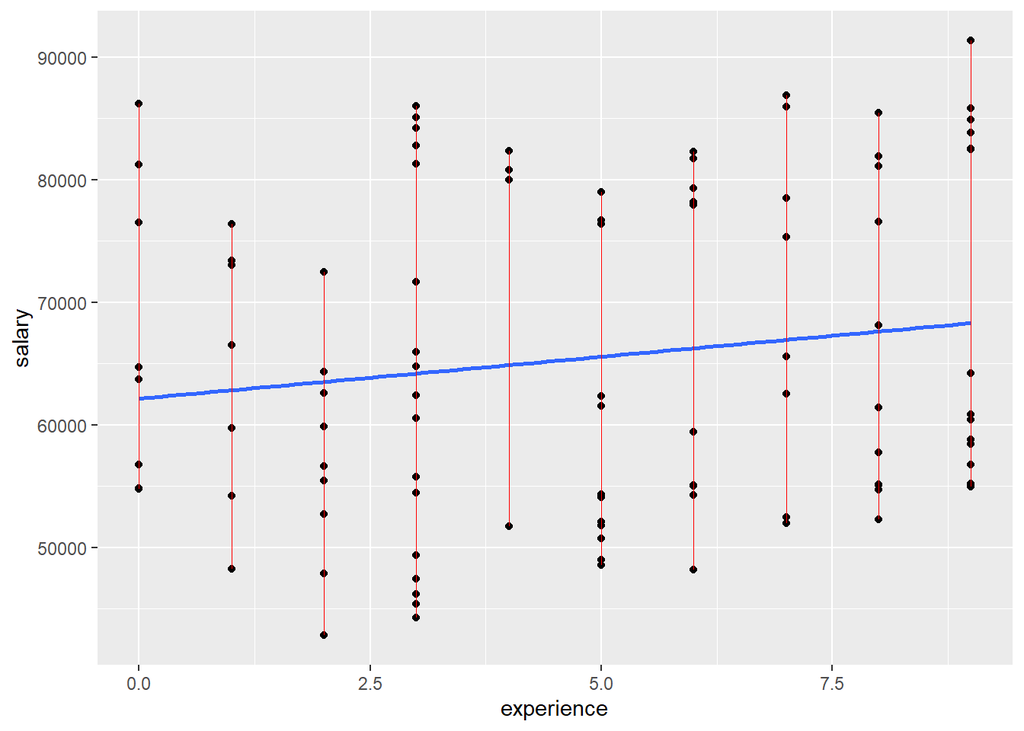

```r
ggplot(data = m1_results,
       aes(x = experience, y = salary)) +
  geom_point() +
  geom_smooth(method = lm, se = FALSE) +
  geom_segment(aes(xend = experience, yend = .fitted), color = "red", size = 0.3)
```

## 4.3 The four assumptions of the linear model:

1. **Linearity** - The relationship between the explanatory variable ($X$) and the response variable ($Y$) must be linear.
2. **Normality**- The residual must be approximately normally distributed.
3. **Homoscedasticity**- The residuals are should have a constant variance.
4. **Independence**- There should be no relationship between the residuals and the response variable ($Y$).

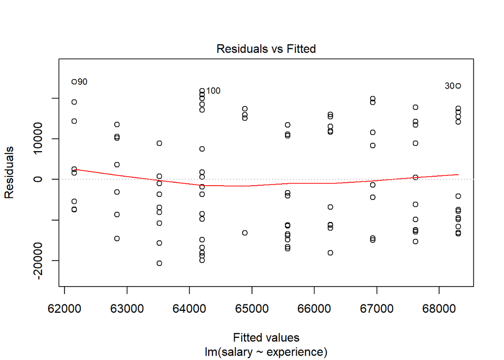

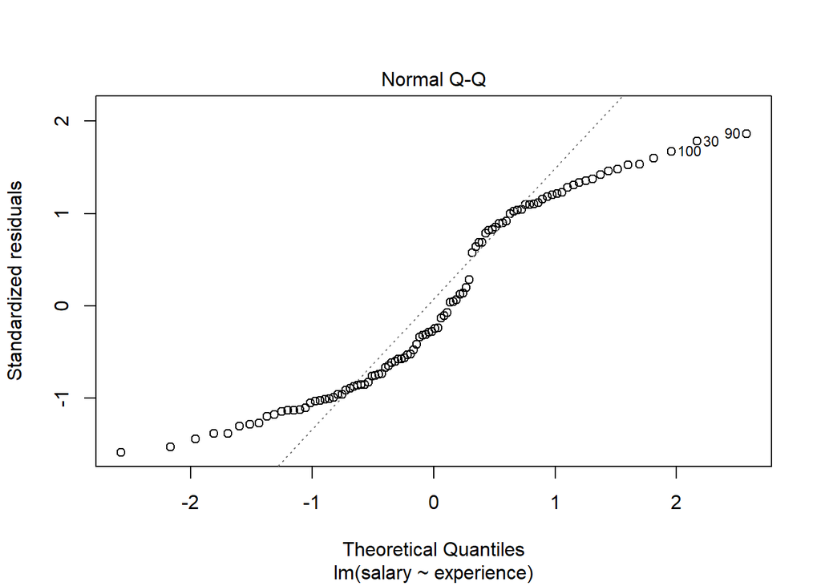

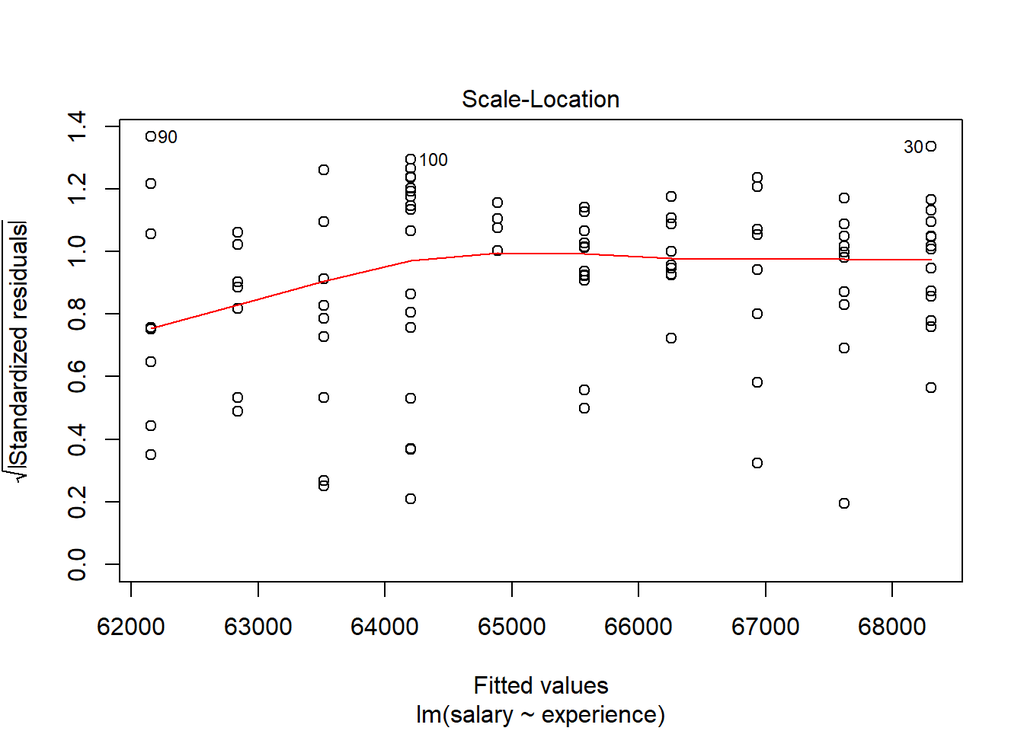

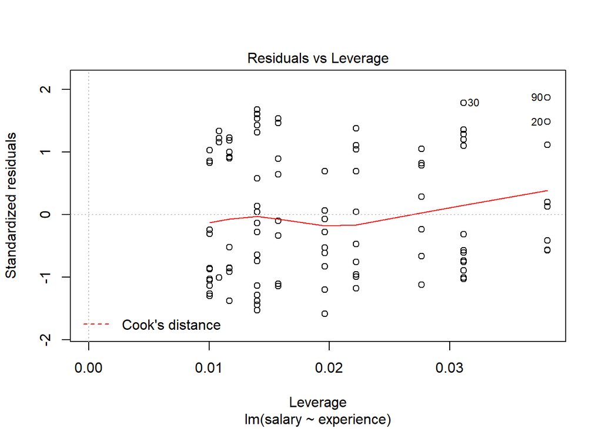

```r
plot(m1)
```

## 4.4 Each department has a different starting salary but the increase in salary with experience is the same.

Our data is “nested”, that is we have groups within our data. We can add group, the department, as a third variable as the colour.

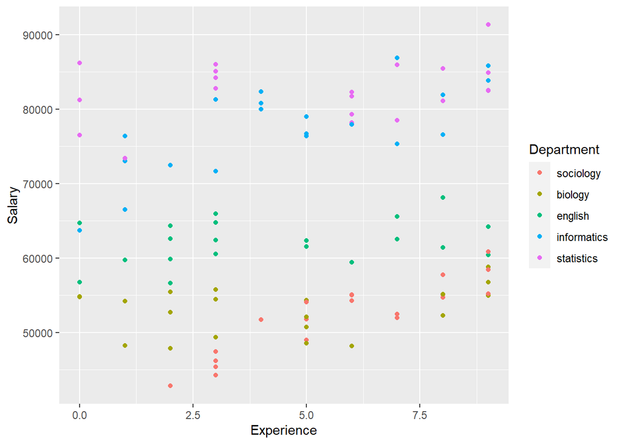

```r
ggplot(data = salaries) +
  geom_point(aes(x = experience, y = salary, color = department)) +
  labs(x="Experience", y="Salary") +
  scale_colour_discrete('Department')
```

- How does the formula change if we think each group may have a different starting salary?

```r
m2  <- lm(salary ~ experience + department, data = salaries)
```

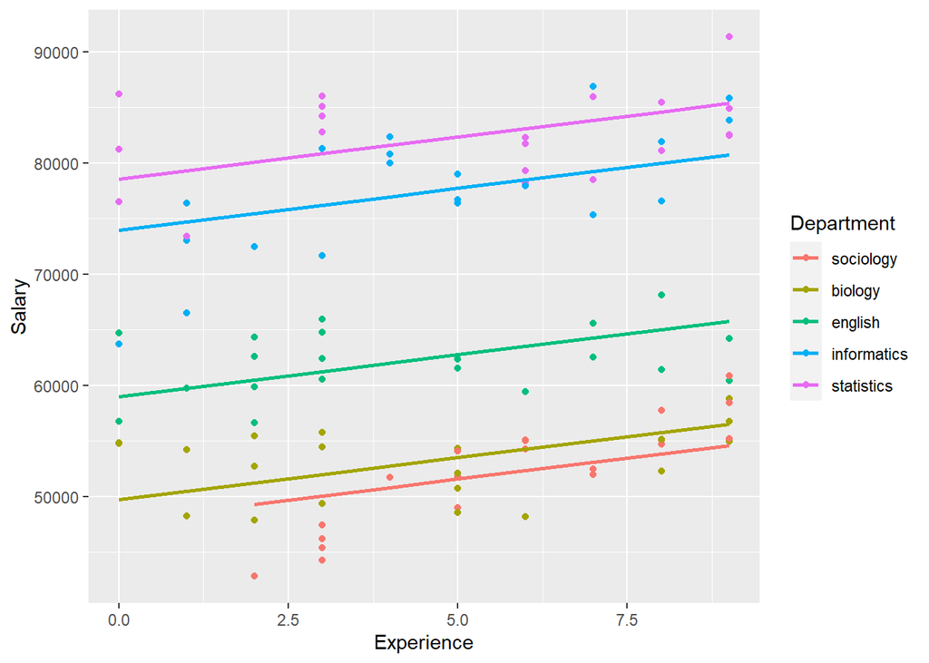

```r
m2_results <- broom::augment(m2)

ggplot(data = m2_results,
       aes(x = experience, y = salary, colour = department)) +
  geom_point() +
  labs(x="Experience", y="Salary") +
  scale_colour_discrete('Department') +
  geom_line(aes(y = .fitted), size = 1)
```

* Let’s take a look again at those residuals

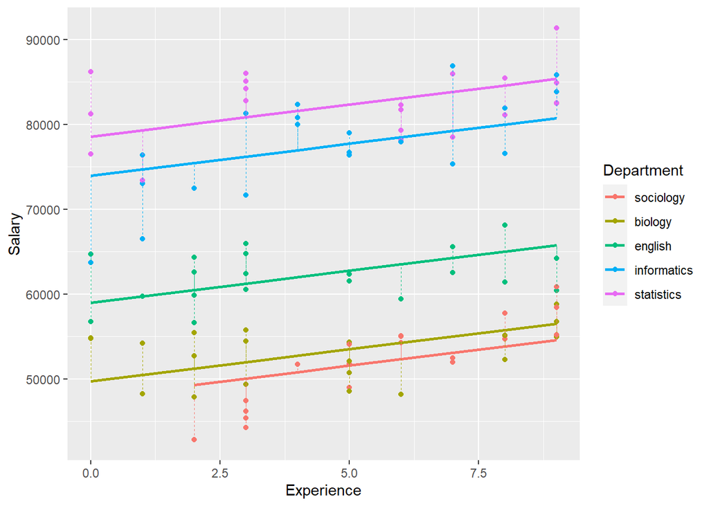

```r
ggplot(data = m2_results,
       aes(x = experience, y = salary, colour = department)) +
  geom_point() +
  labs(x="Experience", y="Salary") +
  scale_colour_discrete('Department') +
  geom_line(aes(y = .fitted), size = 1) +
  geom_segment(aes(xend = experience, yend = .fitted, colour = department), size = 0.3, linetype = 2)
```

```r
summary(m2)
```

```
##
## Call:
## lm(formula = salary ~ experience + department, data = salaries)
##
## Residuals:
##      Min       1Q   Median       3Q      Max
## -10216.7  -2802.8   -222.6   2818.7   7639.0
##
## Coefficients:
##                       Estimate Std. Error t value Pr(>|t|)
## (Intercept)            47800.2     1152.5  41.477  < 2e-16 ***
## experience               755.5      134.6   5.611 2.02e-07 ***
## departmentbiology       1933.6     1215.5   1.591    0.115
## departmentenglish      11180.0     1216.6   9.189 9.74e-15 ***
## departmentinformatics  26151.2     1209.4  21.623  < 2e-16 ***
## departmentstatistics   30768.2     1201.8  25.602  < 2e-16 ***
## ---
## Signif. codes:  0 '***' 0.001 '**' 0.01 '*' 0.05 '.' 0.1 ' ' 1
##
## Residual standard error: 3790 on 94 degrees of freedom
## Multiple R-squared:  0.9219, Adjusted R-squared:  0.9178
## F-statistic:   222 on 5 and 94 DF,  p-value: < 2.2e-16
```

- Let’s inspect the residual plots again

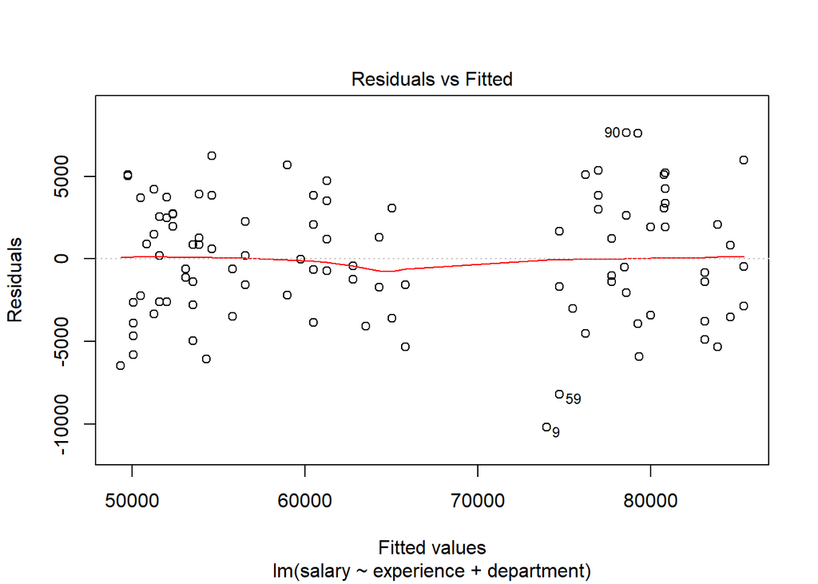

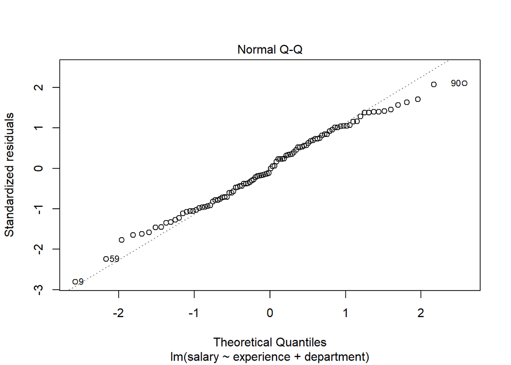

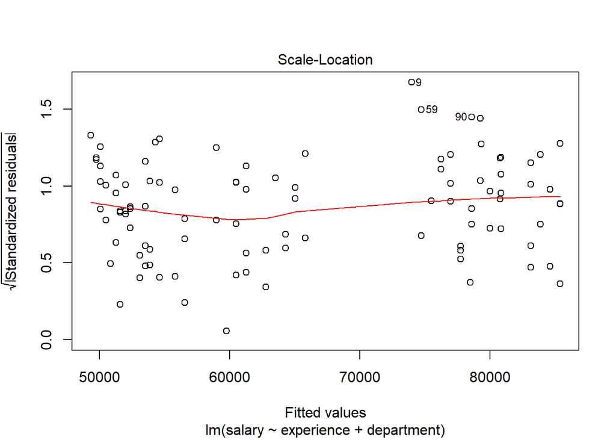

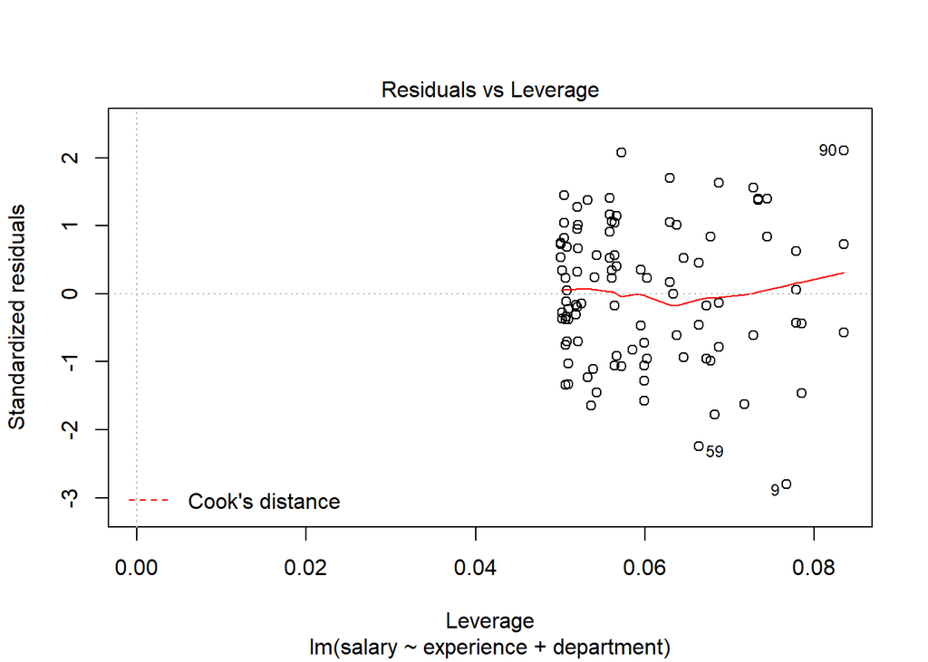

```r
plot(m2)
```

If someone works in a department for 6 years, will they have a higher salary if they are in the biology or sociology department?

```r
m2_coef <- coef(m2)

names(m2_coef)
```

```
## [1] "(Intercept)"           "experience"            "departmentbiology"
## [4] "departmentenglish"     "departmentinformatics" "departmentstatistics"
```

```r
biology_ex6 <- m2_coef["(Intercept)"] + m2_coef["departmentbiology"] + 6*m2_coef["experience"]


sociology_ex6 <- m2_coef["(Intercept)"] + 6*m2_coef["experience"]
```

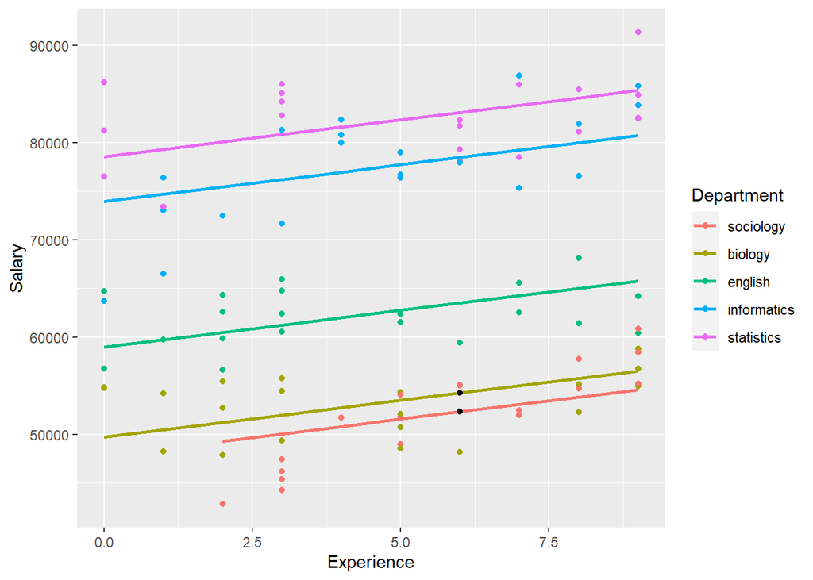

```r
m2_results <- broom::augment(m2)

ggplot(data = m2_results,
       aes(x = experience, y = salary, colour = department)) +
  geom_point() +
  labs(x="Experience", y="Salary") +
  scale_colour_discrete('Department') +
  geom_line(aes(y = .fitted), size = 1) +
  geom_point(aes(x = 6, y = biology_ex6), color = "black") +
  geom_point(aes(x = 6, y = sociology_ex6), color = "black")
```

## 4.5 Each department has different starting salaries and salaries increase at different rates.

```r
m3 <- lm(salary ~ experience*department, data = salaries)

m3_results <- broom::augment(m3)
```

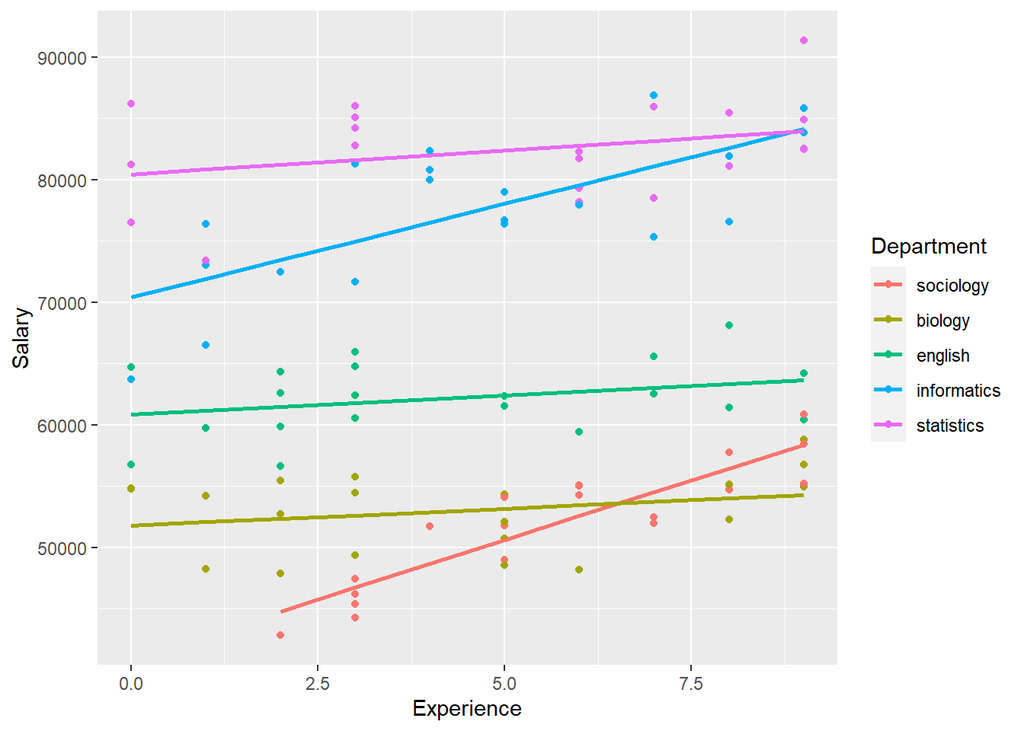

```r
ggplot(data = m3_results,
       aes(x = experience, y = salary, color = department)) +
  geom_point() +
  labs(x="Experience", y="Salary") +
  scale_colour_discrete('Department') +
  geom_line(aes(y = .fitted), size = 1)
```

- Plot with the residuals

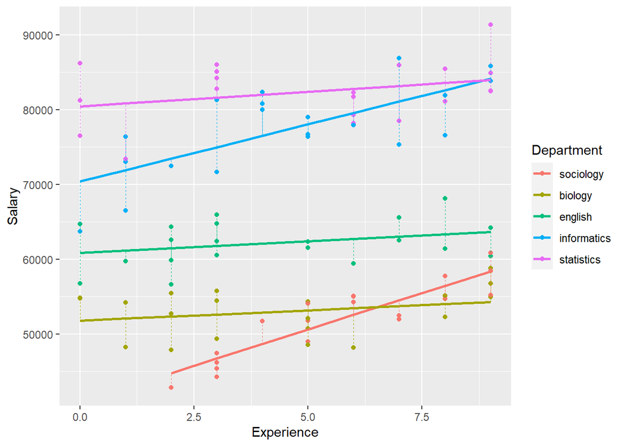

```r
ggplot(data = m3_results,
       aes(x = experience, y = salary, color = department)) +
  geom_point() +
  labs(x = "Experience", y = "Salary") +
  scale_colour_discrete('Department') +
  geom_line(aes(y = .fitted), size = 1) +
  geom_segment(aes(xend = experience, yend = .fitted, colour = department), size = 0.3, linetype = 2)
```

- Summary of the model

```r
summary(m3)
```

```
##
## Call:
## lm(formula = salary ~ experience * department, data = salaries)
##
## Residuals:
##     Min      1Q  Median      3Q     Max
## -7437.8 -1989.7   -23.6  2519.5  7383.5
##
## Coefficients:
##                                  Estimate Std. Error t value Pr(>|t|)
## (Intercept)                       40923.7     2102.3  19.466  < 2e-16 ***
## experience                         1941.1      338.4   5.736 1.28e-07 ***
## departmentbiology                 10877.4     2483.2   4.380 3.19e-05 ***
## departmentenglish                 19933.3     2495.1   7.989 4.30e-12 ***
## departmentinformatics             29483.2     2569.6  11.474  < 2e-16 ***
## departmentstatistics              39529.6     2547.5  15.517  < 2e-16 ***
## experience:departmentbiology      -1666.4      422.2  -3.947 0.000157 ***
## experience:departmentenglish      -1627.2      427.8  -3.803 0.000260 ***
## experience:departmentinformatics   -415.1      436.9  -0.950 0.344597
## experience:departmentstatistics   -1551.6      413.7  -3.751 0.000312 ***
## ---
## Signif. codes:  0 '***' 0.001 '**' 0.01 '*' 0.05 '.' 0.1 ' ' 1
##
## Residual standard error: 3370 on 90 degrees of freedom
## Multiple R-squared:  0.9409, Adjusted R-squared:  0.935
## F-statistic: 159.2 on 9 and 90 DF,  p-value: < 2.2e-16
```